# Exercise1 : Your First Map

Python

Code

Geopandas

Author

Jinwon Lee

Published

April 29, 2023

> Kaggle Geospatial Analysis Exercise 1

**이 노트북은 Kaggle [Geospatial Analysis](https://www.kaggle.com/learn/geospatial-analysis)의 Exercise 입니다. 이 [링크](https://jw0112.github.io/blog/Data_Mining/Geospatial_Analysis/Geospatial_Analysis#lesson-1-your-first-map)로 튜토리얼을 볼 수 있습니다.**

# 소개

[**Kiva**](https://www.kiva.org/) 는 전 세계 빈곤층에게 금융 서비스를 제공하는 온라인 크라우드펀딩 플랫폼입니다. Kiva의 대출자들은 200만명 이상의 사람들에게 10억 달러 이상의 대출을 제공했습니다.

[figure not shown]

Kiva는 전 세계 ‘현장 파트너’ 네트워크를 통해 세계에서 가장 외진 곳까지 도달합니다. 이러한 파트너는 지역 사회에서 대출자를 심사하고, 서비스를 제공하며, 대출을 관리하는 지역 단체입니다.

이 Exercise에서는 필리핀의 Kiva 대출을 조사하게 됩니다. 새로운 현장 파트너를 모집할 기회를 찾기 위해 현재 Kiva의 네트워크 밖에 있을 수 있는 지역을 파악할 수 있나요?

```python
import geopandas as gpd
```

### 1) 데이터 불러오기

다음 셀을 사용하여 `loans_filepath`에 있는 shapefile을 로드하여 GeoDataFrame `world_loans`를 만듭니다.

```python
loans_filepath = './geospatial-learn-course-data/kiva_loans/kiva_loans/kiva_loans.shp'
world_loans =  gpd.read_file(loans_filepath)
world_loans.head()
```

|  | Partner ID | Field Part | sector | Loan Theme | country | amount | geometry |
| --- | --- | --- | --- | --- | --- | --- | --- |
| 0 | 9 | KREDIT Microfinance Institution | General Financial Inclusion | Higher Education | Cambodia | 450 | POINT (102.89751 13.66726) |
| 1 | 9 | KREDIT Microfinance Institution | General Financial Inclusion | Vulnerable Populations | Cambodia | 20275 | POINT (102.98962 13.02870) |
| 2 | 9 | KREDIT Microfinance Institution | General Financial Inclusion | Higher Education | Cambodia | 9150 | POINT (102.98962 13.02870) |
| 3 | 9 | KREDIT Microfinance Institution | General Financial Inclusion | Vulnerable Populations | Cambodia | 604950 | POINT (105.31312 12.09829) |
| 4 | 9 | KREDIT Microfinance Institution | General Financial Inclusion | Sanitation | Cambodia | 275 | POINT (105.31312 12.09829) |

### 2) 데이터 시각화

다음 셀을 실행하여 국가 경계가 포함된 `world` GeoDataFrame을 로드합니다.

```python
world_filepath = gpd.datasets.get_path('naturalearth_lowres')
world = gpd.read_file(world_filepath)
world.head()
```

|  | pop_est | continent | name | iso_a3 | gdp_md_est | geometry |
| --- | --- | --- | --- | --- | --- | --- |
| 0 | 889953.0 | Oceania | Fiji | FJI | 5496 | MULTIPOLYGON (((180.00000 -16.06713, 180.00000... |
| 1 | 58005463.0 | Africa | Tanzania | TZA | 63177 | POLYGON ((33.90371 -0.95000, 34.07262 -1.05982... |
| 2 | 603253.0 | Africa | W. Sahara | ESH | 907 | POLYGON ((-8.66559 27.65643, -8.66512 27.58948... |
| 3 | 37589262.0 | North America | Canada | CAN | 1736425 | MULTIPOLYGON (((-122.84000 49.00000, -122.9742... |
| 4 | 328239523.0 | North America | United States of America | USA | 21433226 | MULTIPOLYGON (((-122.84000 49.00000, -120.0000... |

`world`와 `world_loans` GeoDataFrame을 사용하여 전 세계의 Kiva 대출 위치를 시각화합니다.

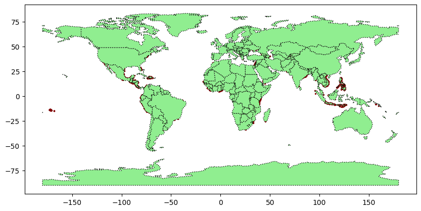

```python
ax = world.plot(figsize = (10, 10), color = 'lightgreen', linestyle = ':', edgecolor = 'black', zorder = 3)
world_loans.plot(color = 'maroon', markersize = 2, ax = ax)
```

### 3) 필리핀 대출 선택

다음으로 필리핀에 기반을 둔 대출에 초점을 맞춥니다. 다음 셀을 사용하여 필리핀에 기반을 둔 대출이 있는 `world_loans`의 모든 행을 포함하는 GeoDataFrame `PHL_loans`를 만듭니다.

```python
PHL_loans = world_loans[world_loans['country'] == 'Philippines']
PHL_loans.head()
```

|  | Partner ID | Field Part | sector | Loan Theme | country | amount | geometry |
| --- | --- | --- | --- | --- | --- | --- | --- |
| 2859 | 123 | Alalay sa Kaunlaran (ASKI) | General Financial Inclusion | General | Philippines | 400 | POINT (121.73961 17.64228) |
| 2860 | 123 | Alalay sa Kaunlaran (ASKI) | General Financial Inclusion | General | Philippines | 400 | POINT (121.74169 17.63235) |
| 2861 | 123 | Alalay sa Kaunlaran (ASKI) | General Financial Inclusion | General | Philippines | 400 | POINT (121.46667 16.60000) |
| 2862 | 123 | Alalay sa Kaunlaran (ASKI) | General Financial Inclusion | General | Philippines | 6050 | POINT (121.73333 17.83333) |
| 2863 | 123 | Alalay sa Kaunlaran (ASKI) | General Financial Inclusion | General | Philippines | 625 | POINT (121.51800 16.72368) |

### 4) 필리핀 대출 이해

다음 셀을 실행하여 필리핀의 모든 섬에 대한 경계가 포함된 `PHL` GeoDataFrame을 로드합니다.

```python
gpd.io.file.fiona.drvsupport.supported_drivers['KML'] = 'rw'
PHL = gpd.read_file('./geospatial-learn-course-data/Philippines_AL258.kml', driver = 'KML')
PHL.head()
```

|  | Name | Description | geometry |
| --- | --- | --- | --- |
| 0 | Autonomous Region in Muslim Mindanao |  | MULTIPOLYGON (((119.46690 4.58718, 119.46653 4... |
| 1 | Bicol Region |  | MULTIPOLYGON (((124.04577 11.57862, 124.04594 ... |
| 2 | Cagayan Valley |  | MULTIPOLYGON (((122.51581 17.04436, 122.51568 ... |
| 3 | Calabarzon |  | MULTIPOLYGON (((120.49202 14.05403, 120.49201 ... |
| 4 | Caraga |  | MULTIPOLYGON (((126.45401 8.24400, 126.45407 8... |

`PHL`와 `PHL_loans` GeoDataFrame을 사용하여 필리핀의 대출 위치를 시각화합니다.

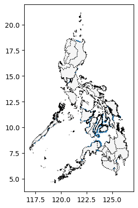

```python
ax = PHL.plot(figsize = (5, 5), color = 'whitesmoke', linestyle = ':', edgecolor = 'black', zorder = 3)
PHL_loans.plot(markersize = 4, ax = ax)
```

새로운 현장 파트너를 모집하는 데 도움이 될 만한 섬을 식별할 수 있나요? 현재 Kiva의 손이 닿지 않는 섬이 있나요?

이 지도가 질문에 답하는 데 유용할 수 있습니다.

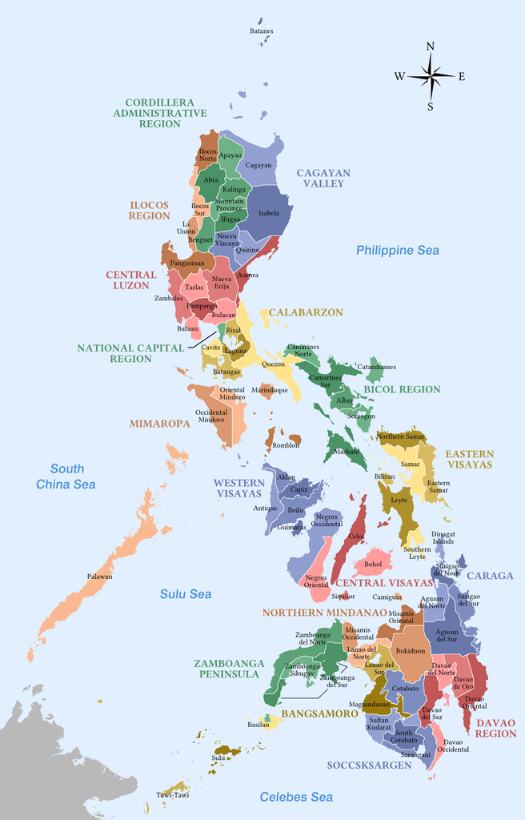

여러 잠재적 섬이 있지만, 현재 데이터 세트에서 대출이 없는 비교적 큰 섬으로 **민도로(필리핀 중부)** 가 눈에 띕니다.

이 섬은 새로운 필드 파트너를 모집하기에 좋은 장소가 될 수 있습니다!

# 그 다음은?

**[Lesson 2 : Coordinate Reference Systems](https://jw0112.github.io/blog/Data_Mining/Geospatial_Analysis/Geospatial_Analysis#lesson-2-coordinate-reference-systems)에 대해서 알아보세요.**

*Have questions or comments? Visit the [course discussion forum](https://www.kaggle.com/learn/geospatial-analysis/discussion) to chat with other learners.*